# Black Friday Analysis

Sanata Sy-Sahande

October 22, 2018

In this document, I first do some exploratory data analysis on the Black Friday dataset. I then run several prediction models to predict the amount purchased by a customer, and classification models to predict the product category of the purchase.

## Exploratory analysis

The dataset includes information on about 5800+ customers, for about 3600+ products.

```r
length(unique(bf$Product_ID)) #3k+ products
```

```
## [1] 3623
```

```r
length(unique(bf$User_ID)) #6K customers
```

```
## [1] 5891
```

The average purchase is about $9300, and the variable is normally distributed, with spikes at $15000 and $20000.

```r
mean(bf$Purchase)
```

```
## [1] 9333.86
```

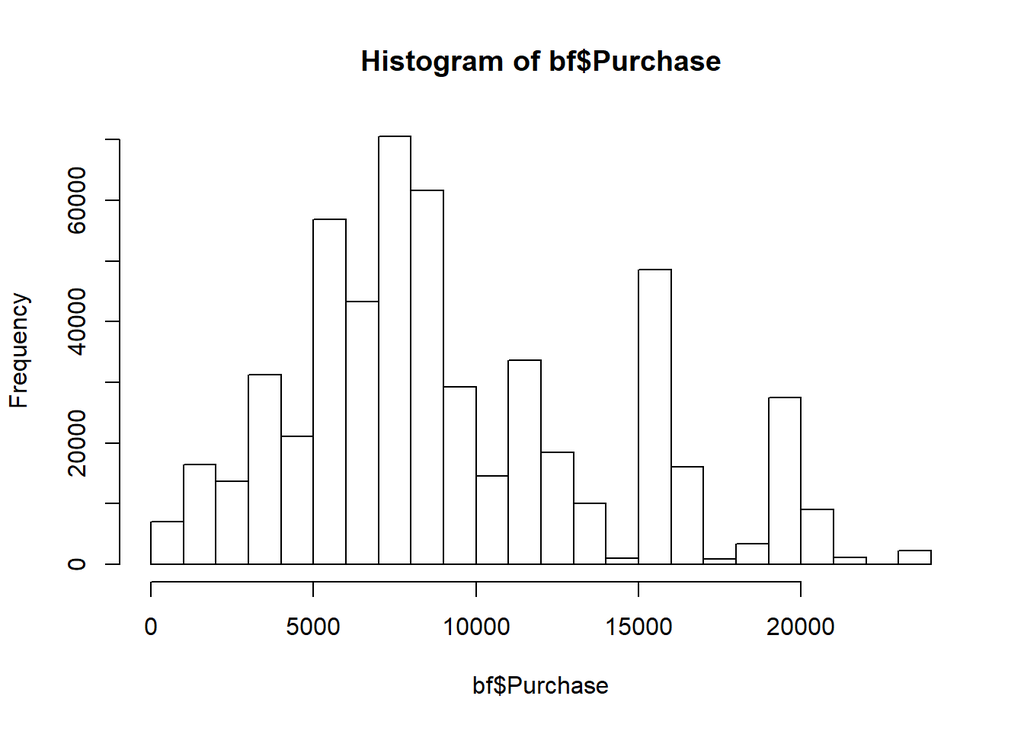

```r
hist(bf$Purchase)
```

# Purchases as a function of features

The next series of plots show how purchase amounts vary by the other variables in the dataset.

At first glance age, gender (men), and product category seem to be the best predictors of amount purchased.

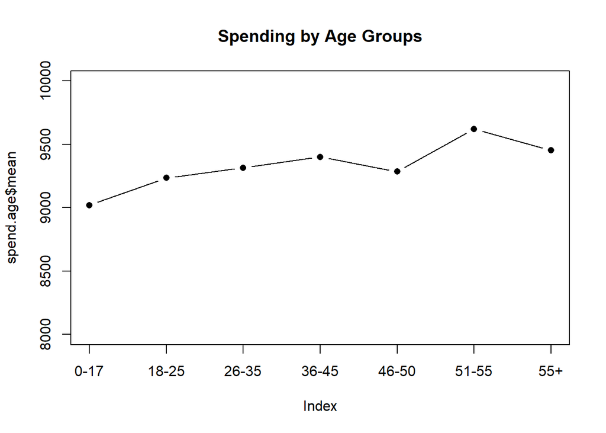

```r
#by age
spend.age <- bf %>% group_by(Age) %>%
              summarise(mean = mean(Purchase))

plot(spend.age$mean, xaxt="n", pch=16, ylim=c(8000, 10000), type='b',
     main = "Spending by Age Groups")
axis(1, 1:7, labels=spend.age$Age)
```

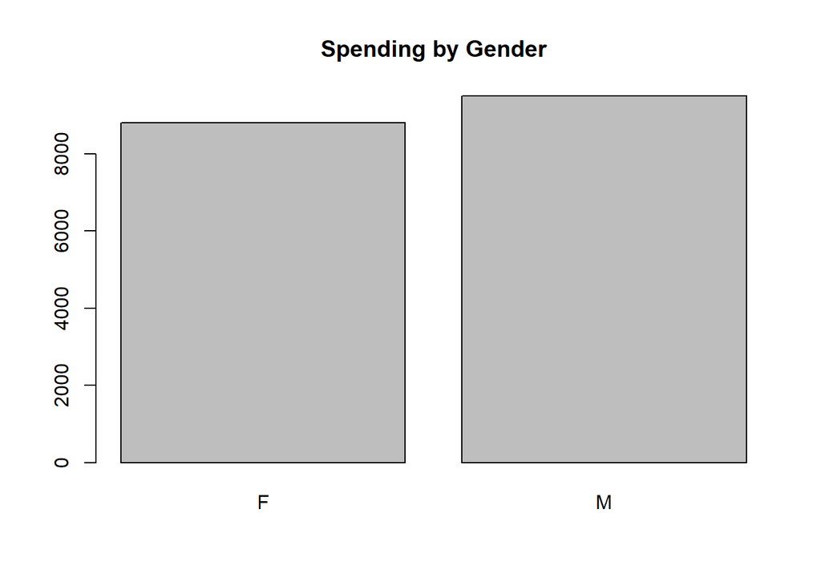

```r
#by gender
spend.gender <- bf %>% group_by(Gender) %>%
                    summarise(mean = mean(Purchase))
barplot(spend.gender$mean, names=spend.gender$Gender,
        main = "Spending by Gender")
```

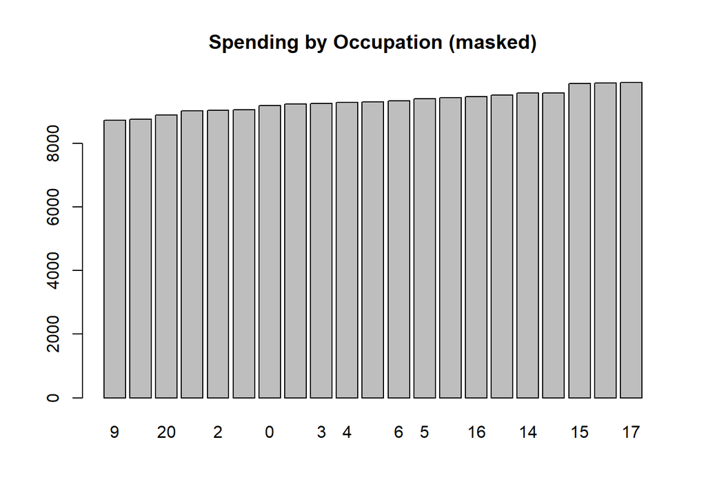

```r
#by occupation
spend.occ <- bf %>% group_by(Occupation) %>%
                 summarise(mean = mean(Purchase)) %>% arrange(mean)
barplot(spend.occ$mean, names=spend.occ$Occupation,
        main = "Spending by Occupation (masked)")
```

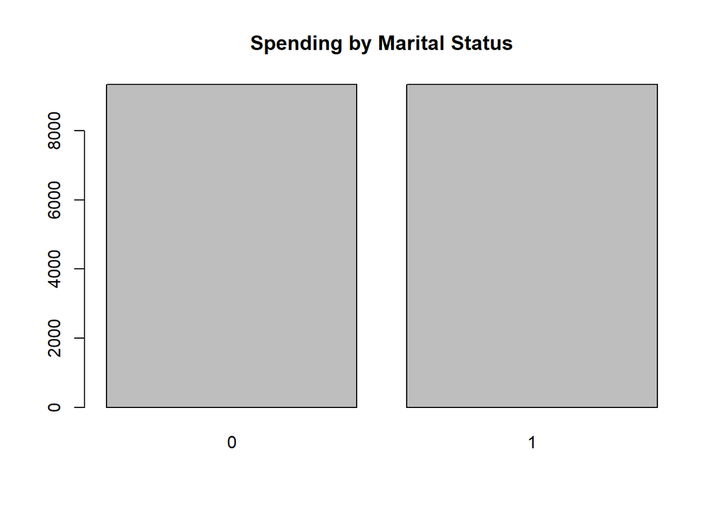

```r
#by marital status
spend.mar <- bf %>% group_by(Marital_Status) %>%
              summarise(mean = mean(Purchase)) %>% arrange(mean)
barplot(spend.mar$mean, names=spend.mar$Marital_Status,
        main = "Spending by Marital Status")
```

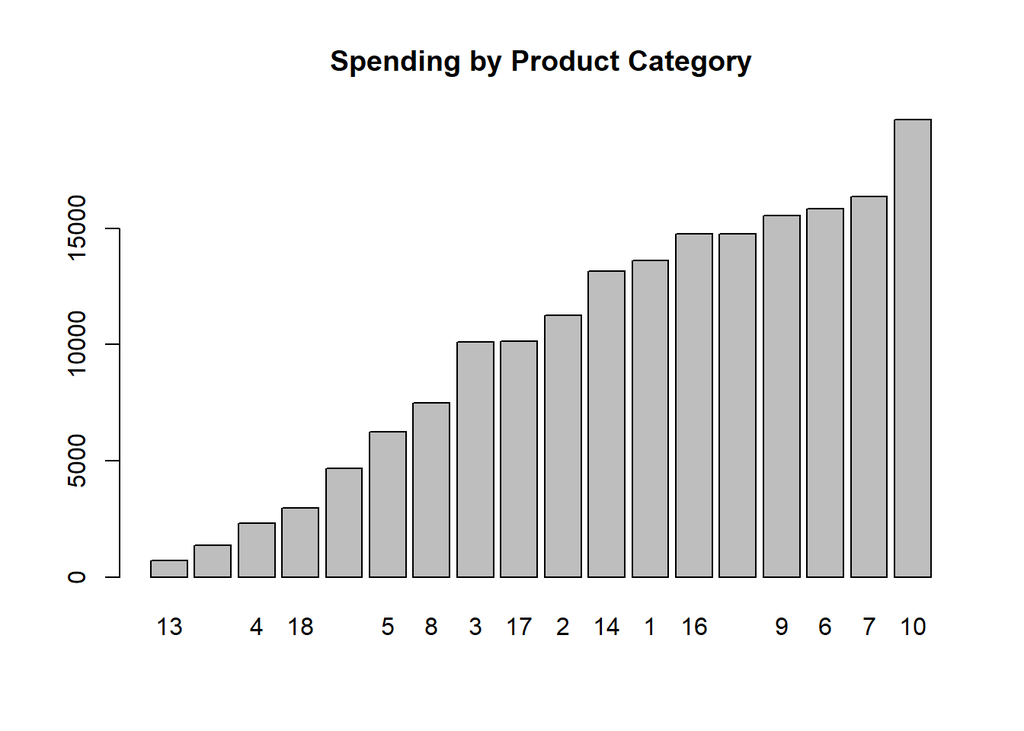

```r
#by category
spend.cat <- bf %>% group_by(Product_Category_1) %>%
              summarise(mean = mean(Purchase)) %>% arrange(mean)
barplot(spend.cat$mean, names=spend.cat$Product_Category_1,
        main = "Spending by Product Category")
```

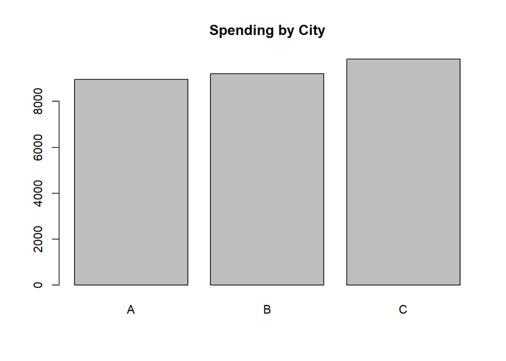

```r
#by city
spend.city <- bf %>% group_by(City_Category) %>%
                summarise(mean = mean(Purchase)) %>% arrange(mean)
barplot(spend.city$mean, names=spend.city$City_Category,
        main = "Spending by City")
```

Next, I quickly check which product categories are most popular. Categories 1, 5, and 8 outnumber all other categories. This issue will come up later in the classification models.

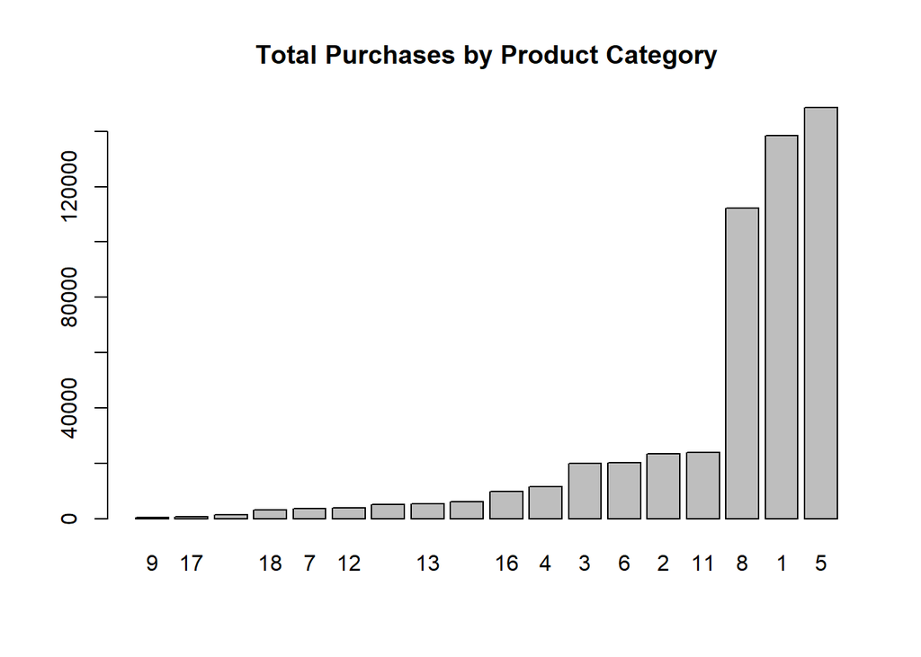

```r
##number of purchases per category
n.cat <- bf %>% group_by(Product_Category_1) %>%
              summarise(n = n()) %>% arrange(n)
barplot(n.cat$n, names = n.cat$Product_Category_1,
        main = "Total Purchases by Product Category")
```

I then check whether some categories just have more products, which would explain their popularity. Again, I find categories 1, 5, and 8 have the most products.

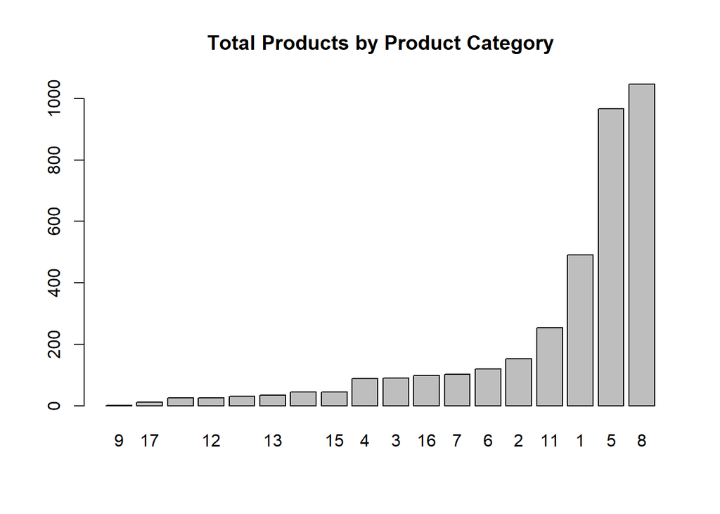

```r
##number of products per category
n.prod <- bf %>% group_by(Product_Category_1) %>%
  summarise(nprod = n_distinct(Product_ID)) %>% arrange(nprod)
barplot(n.prod$nprod, names = n.prod$Product_Category_1,
        main = "Total Products by Product Category")
```

# Data cleaning

I did some data cleaning to add and edit variables.

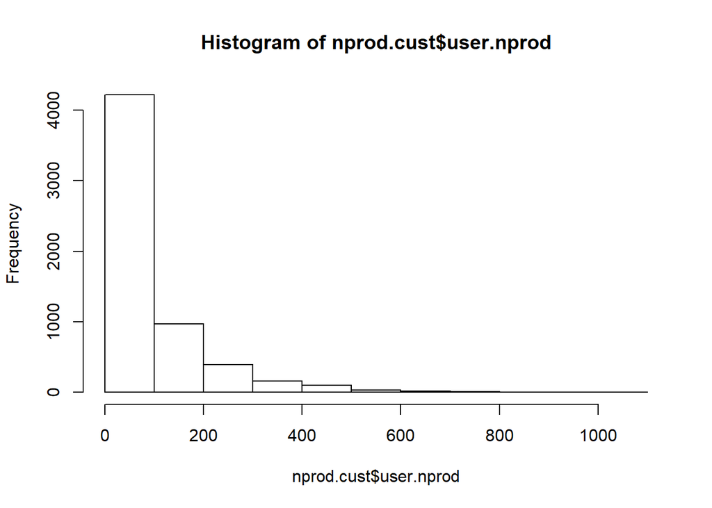

```r
#Data cleaning: product and purchase by customer
nprod.cust <- bf %>% group_by(User_ID) %>%
        summarise(user.nprod = n_distinct(Product_ID))
hist(nprod.cust$user.nprod)
```

```r
summary(nprod.cust$user.nprod)
```

```
##    Min. 1st Qu.  Median    Mean 3rd Qu.    Max.
##    5.00   25.00   53.00   91.25  114.00 1025.00
```

```r
purch.cust <- bf %>% group_by(User_ID) %>%
              summarise(totspend = sum(Purchase))
#add to dataset
bf <- left_join(bf, nprod.cust, by="User_ID")
bf <- left_join(bf, purch.cust, by="User_ID")


#Data cleaning: drop variables
#Dropping cat2 and cat3 vars to simplify classification
bf <- bf %>% select(-Product_Category_2, -Product_Category_3)

#Data cleaning: edit variables
bf <- bf %>% mutate(Age = recode(Age, "0-17"=0,
                                      "18-25"=1,
                                      "26-35"=2,
                                      "36-45"=3,
                                      "46-50"=4,
                                      "51-55"=5,
                                      "55+"=6))
bf <- bf %>% mutate(Stay_In_Current_City_Years =
                      recode(Stay_In_Current_City_Years,
                              "0"=0, "1"=1, "2"=2, "3"=3, "4+"=4))

#Data cleaning: convert to factors
bf$Gender <- as.factor(bf$Gender)
bf$Occupation <- as.factor(bf$Occupation)
bf$City_Category <- as.factor(bf$City_Category )
bf$Product_Category_1 <- as.factor(bf$Product_Category_1)
```

# Regression: Predict Purchase Amount

I run several models to predict Purchase based on customer features. I first calculate the baseline RMSE with a simple OLS regression.

```r
#Data prep: make training and validation
set.seed(1)
train = sample(1:nrow(bf), nrow(bf)/2)

#LINEAR REG
lm.bf <- lm(Purchase ~ Gender + Age + Occupation +
              City_Category + Stay_In_Current_City_Years +
              Marital_Status,
              data=bf[train, ])
#predict
yhat = predict(lm.bf, newdata=bf[-train, ])
mse <- mean((bf$Purchase[-train] - yhat)^2)
sqrt(mse)
```

```
## [1] 4957.321
```

**Feature Selection**

To improve on the OLS model, I do some feature engineering to select the best variables to keep. This is especially useful since the dataset includes two categorical variables with many levels: occupation (21 levels) and product category (18 levels). Together they add almost 40 features to the model.

I first determine the optimal number of variables to include in the model. I compare full subset selection, forward, and backward selection. I use adjusted R-squared as my evaluation metric.

Below are the results of the forward selection approach, whichindicates about 10 variables before the improvement in adjusted R-squared from adding additional variables becomes neglible. (Similar results for full and backward selection ommitted.)

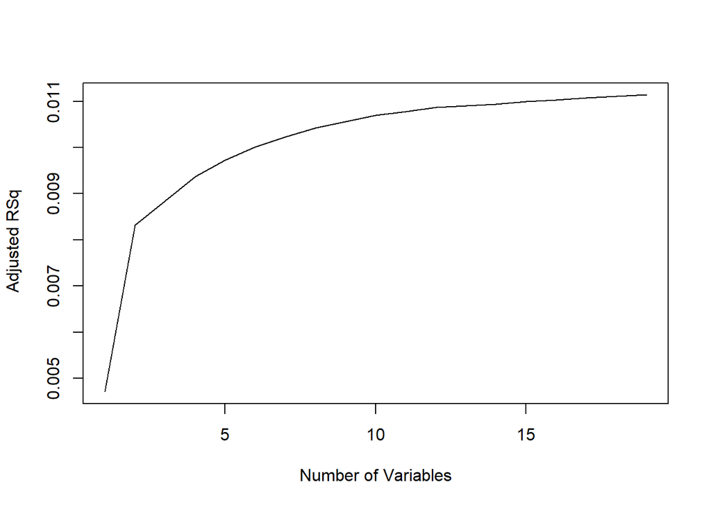

```r
library(leaps)
#forward selection
regfit.fwd = regsubsets(Purchase ~ Gender + Age + Occupation +
                            City_Category +
                           Stay_In_Current_City_Years +
                           Marital_Status, bf, nvmax=19,
                        method = "forward")
reg.summary = summary(regfit.fwd)

plot(reg.summary$adjr2 ,xlab =" Number of Variables ",
     ylab=" Adjusted RSq",type="l")
```

```r
which.max(reg.summary$adjr2)
```

```
## [1] 19
```

```r
fwd.coefs <- coef(regfit.fwd, 10)
fwd.coefs
```

```
##    (Intercept)        GenderM    Occupation7   Occupation12   Occupation14
##      8402.4806       631.8746       198.5486       524.4904       339.5393
##   Occupation15   Occupation17   Occupation19   Occupation20 City_CategoryB
##       587.0321       506.2131      -505.8988      -247.4482       230.3504
## City_CategoryC
##       850.1810
```

```r
#First, create a vector that allocates each observation to one of k = 10 folds
k=10
set.seed(1)
folds=sample(1:k,nrow(bf),replace =TRUE)
cv.errors = matrix(NA, k, 15, dimnames=list(NULL, paste(1:15) )) #matrix to store results

#make predict function
predict.regsubsets = function(object, newdata ,id ,...){
  form = as.formula(object$call[[2]])
  mat = model.matrix(form, newdata)
  coefi = coef(object, id=id)
  xvars =names (coefi )
  mat[,xvars ]%*% coefi
}

#In the jth fold, the elements of folds that equal j
#are in the test set, and the remainder are in the training set
for(j in 1:k){
  best.fit = regsubsets(Purchase ~ Gender + Age + Occupation +
                            City_Category +
                           Stay_In_Current_City_Years +
                           Marital_Status,
                          data=bf[folds !=j,],
                          nvmax =15)
  for(i in 1:15) {
    pred=predict.regsubsets(best.fit, bf[folds==j,], id=i) #make predictions for each model size
    #compute the test errors on the appropriate subset
    #store them in cv.errors
    cv.errors[j,i]=mean( (bf$Purchase[folds==j]-pred)^2)
  }
  #returns a kx15 matrix in cv.errors
}

mean.cv.errors = apply(cv.errors ,2, mean) #calculate errors for the j-variable model
mean.cv.errors
```

```
##        1        2        3        4        5        6        7        8
## 24694029 24604631 24591561 24578726 24569726 24562970 24557629 24552690
##        9       10       11       12       13       14       15
## 24550119 24545840 24545483 24541803 24541852 24539767 24538128
```

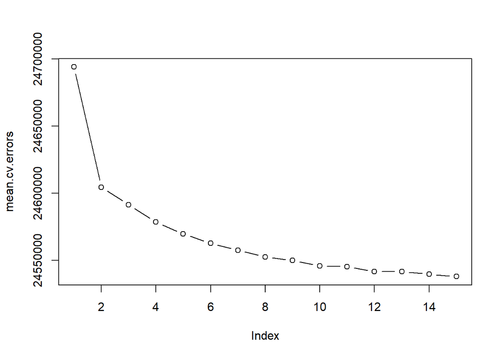

```r
par(mfrow =c(1,1))
plot(mean.cv.errors ,type='b')
```

As an alternative, I used cross-validation to determine the optimal number of variables in the model. I did this by performing best subset selection for up to 15 variables, within each of k=10 training sets. The results seem to confirm that 10-15 is the ideal range of variables. I select 12, and obtain the best 12 coefficients from the best subset method on the full sample.

```r
reg.best = regsubsets(Purchase ~ Gender + Age + Occupation +
                            City_Category +
                           Stay_In_Current_City_Years +
                           Marital_Status, data=bf, nvmax=15)
coef(reg.best, 12)
```

```
##    (Intercept)        GenderM    Occupation1    Occupation7   Occupation10
##      8442.5744       623.7108      -175.2640       162.5461      -324.1805
##   Occupation12   Occupation14   Occupation15   Occupation17   Occupation19
##       488.8330       303.1415       550.9439       470.3583      -542.4365
##   Occupation20 City_CategoryB City_CategoryC
##      -283.1242       230.6716       857.8575
```

```r
lm.fit <- lm(Purchase ~ Gender +
             (Occupation==1) + (Occupation==7) +
             (Occupation==10) + (Occupation==12) +
             (Occupation==14) + (Occupation==15) +
             (Occupation==17) + (Occupation==19) +
             (Occupation==20) + (City_Category=="B") +
             (City_Category=="C"), data=bf[train, ])
#predict
yhat = predict(lm.fit, newdata=bf[-train, ])
mse <- mean((bf$Purchase[-train] - yhat)^2) #MSE
sqrt(mse)
```

```
## [1] 4958.018
```

Selecting the best subset did not lead to a noticeable improvement in RMSE, which is now at 4958.0177481. This suggests that a linear model may not be the best model for the data. I turn to regression trees instead.

# Regression Trees

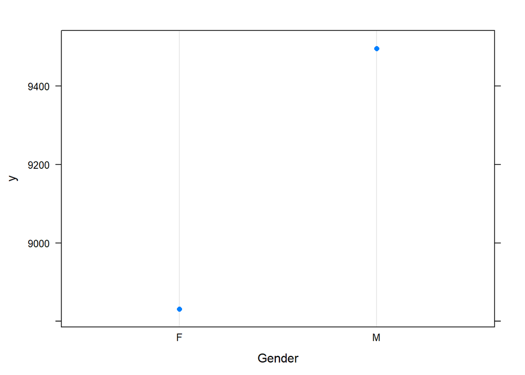

```r
library(gbm)
boost.bf = gbm(Purchase ~ Gender + Age + Occupation +
                 City_Category + Stay_In_Current_City_Years +
                 Marital_Status,
                 data=bf[train, ],
                 distribution="gaussian",  #use ="bernoulli" for classification
                 n.trees=500,
                 interaction.depth = 4) #limit depth of trees


#partial dependence plots:marginal effect of selected vars
par(mfrow=c(1,2))
plot(boost.bf, i="Gender")
```

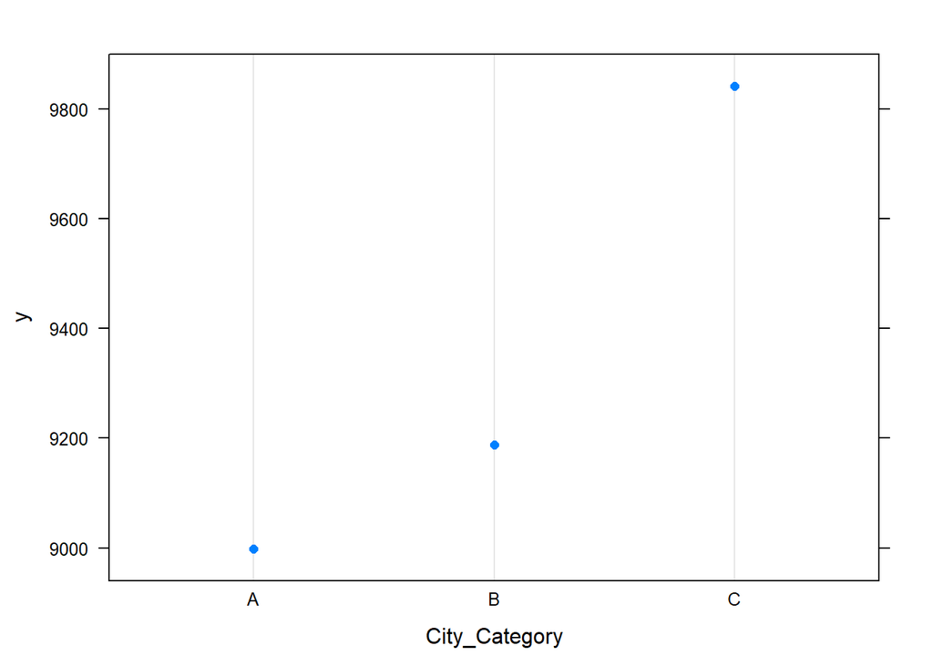

```r
plot(boost.bf, i="City_Category")
```

```r
#predict purchase on test set
yhat.boost=predict(boost.bf, newdata=bf[-train, ], n.trees=500)
mse <- mean((yhat.boost - bf$Purchase[-train])^2)
sqrt(mse) #RMSE = 4932
```

```
## [1] 4933.75
```

Again, the boosted trees reduced the RMSE, but not by much. My guess is that individual characteristics of consumers do not do as great a job of explaining the purchase amount as the products themselves. This is confirmed by comparing the R-squared of the original OLS model, and one including the product categories on the right hand side.

```r
lm.bf <- lm(Purchase ~ Gender + Age + Occupation +
              City_Category + Stay_In_Current_City_Years +
              Marital_Status,
              data=bf[train, ])
sum.lm1 <- summary(lm.bf)
sum.lm1$r.squared
```

```
## [1] 0.01160177
```

```r
lm.bf <- lm(Purchase ~ Gender + Age + Occupation +  Product_Category_1 +
              City_Category + Stay_In_Current_City_Years +
              Marital_Status,
              data=bf[train, ])
sum.lm2 <- summary(lm.bf)
sum.lm2$r.squared
```

```
## [1] 0.6318441
```

As suspected, including product categories increases the training R-squared from 0.01 to 0.63. But this is not particularly informative because it simply indicates that customers who by products from more expensive categories spend more money. It seems then that the appropriate model would be to predict *which categories* of goods customers will buy–a classification problem.

However, before continuing, I make a case for why the prediction models were still informative. Despite their low explanatory power, we now have a better idea of what types of customers tend to spend more: male customers, and those in a set of key occupations (masked). I would expect to see these same features be relevant for the classification models.